# Aprendizaje Profundo

# Minicurso de Ciencia de Datos

## Reducción de Dimensión

## Profesores

1. Alvaro Montenegro, PhD, ammontenegrod@unal.edu.co
2. Campo Elías Pardo, PhD, cepardot@unal.edu.co
3. Daniel Montenegro, Msc, dammontenegrore@unal.edu.co
4. Oleg Jarma, Estadístico, ojarmam@unal.edu.co

## Equipo de Marketing

1. Maria del Pilar Montenegro, pmontenegro88@gmail.com
2. Laura Mondragón, laura.mondragon2125@gmail.com
3. Jessica López, jelopezme@unal.edu.co

## ¿Cuántas dimensiones ves?

[figure not shown]

Un Punto.

[figure not shown]

Una línea.

[figure not shown]

Un cuadrado.

[figure not shown]

Una espiral, por Olha Pohorielova.

[figure not shown]

Un cuadrado lleno.

[figure not shown]

La Tierra, por NASA.

**[Un ejemplo en 4D](https://upload.wikimedia.org/wikipedia/commons/d/d6/8-cell-orig.gif)**

## Flatland: A Romance of Many Dimensions

[figure not shown]

Casa típica en Flatland

¡Vale la pena leerlo! $\to$ Flatland (Quinta Edición): Wikisource

## Midiendo la costa de Gran Bretaña

[figure not shown]

Midiendo con regla gruesa, [CC BY-SA 3.0](http://creativecommons.org/licenses/by-sa/3.0/), [Link](https://commons.wikimedia.org/w/index.php?curid=642220)

[figure not shown]

Midiendo con regla fina, [CC BY-SA 3.0](http://creativecommons.org/licenses/by-sa/3.0/), [Link](https://commons.wikimedia.org/w/index.php?curid=642221)

Si seguimos midiendo con regla más fina:

**a) Tenemos una medida finita (digamos 4000 metros).**

**b) Nunca acabaríamos de medir.**

[Paradoja de la línea de costa](https://en.wikipedia.org/wiki/Coastline_paradox)

## Algunos ejemplos de Fractales

[figure not shown]

Curva de Hilbert, $Dim_H = 2$

[figure not shown]

Conjunto de Mandelbrot. $Dim_H = 2$, $Dim_{Set} = 2$, Created by [CC BY-SA 3.0](http://creativecommons.org/licenses/by-sa/3.0/), [Link](https://commons.wikimedia.org/w/index.php?curid=322029)

[figure not shown]

Triángulo de Sierpinsky. $Dim_H = 1.5850$

[figure not shown]

Curva de Koch. $Dim_H = 1.2619$

¿Alguna vez ha visto un fractal en la vida real?

**a) Sí.**

**b) No.**

**[Lista de Fractales](https://en.wikipedia.org/wiki/List_of_fractals_by_Hausdorff_dimension)**

[figure not shown]

Un Trueno.

[figure not shown]

Romanesco, De [CC BY-SA 3.0](https://creativecommons.org/licenses/by-sa/3.0), [Enlace](https://commons.wikimedia.org/w/index.php?curid=18694671)

[FRACTALS AMONG US](https://hackaday.com/2016/08/18/fractals-among-us/)

[figure not shown]

Paisaje montañoso en Grecia, por dinosmichail.

[figure not shown]

Transporte Anómalo, de Daniel Montenegro.

**Volveremos a esto...**

## ¿Qué significa entonces dimensión?

Existen:

- Dimensión de un Espacio Vectorial.
- Dimensión Topológica.
- Dimensión de Krull.
- Dimensiones Fractales.
- ...

**Informalmente, lo aceptaremos como "el número mínimo" de coordenadas para describir los puntos de un objeto.**

## Ejemplos de Nube de Puntos

[figure not shown]

Fuente: Daniel Montenegro

[figure not shown]

Fuente: Daniel Montenegro

## Las Nubes son Reales

```python
import pandas as pd
import numpy as np

df = pd.read_csv("../datos/auto_clean.csv")
```

Fuente de los Datos: [1985 Automobile Dataset, Kaggle](https://www.kaggle.com/fazilbtopal/auto85)

```python
df.head()
```

|  | symboling | normalized-losses | make | aspiration | num-of-doors | body-style | drive-wheels | engine-location | wheel-base | length | width | height | curb-weight | engine-type | num-of-cylinders | engine-size | fuel-system | bore | stroke | compression-ratio | horsepower | peak-rpm | city-mpg | highway-mpg | price | city-L/100km | horsepower-binned | diesel | gas |
| --- | --- | --- | --- | --- | --- | --- | --- | --- | --- | --- | --- | --- | --- | --- | --- | --- | --- | --- | --- | --- | --- | --- | --- | --- | --- | --- | --- | --- | --- |
| 0 | 3 | 122 | alfa-romero | std | two | convertible | rwd | front | 88.6 | 0.811148 | 0.890278 | 48.8 | 2548 | dohc | four | 130 | mpfi | 3.47 | 2.68 | 9.0 | 111.0 | 5000.0 | 21 | 27 | 13495.0 | 11.190476 | Medium | 0 | 1 |
| 1 | 3 | 122 | alfa-romero | std | two | convertible | rwd | front | 88.6 | 0.811148 | 0.890278 | 48.8 | 2548 | dohc | four | 130 | mpfi | 3.47 | 2.68 | 9.0 | 111.0 | 5000.0 | 21 | 27 | 16500.0 | 11.190476 | Medium | 0 | 1 |
| 2 | 1 | 122 | alfa-romero | std | two | hatchback | rwd | front | 94.5 | 0.822681 | 0.909722 | 52.4 | 2823 | ohcv | six | 152 | mpfi | 2.68 | 3.47 | 9.0 | 154.0 | 5000.0 | 19 | 26 | 16500.0 | 12.368421 | Medium | 0 | 1 |
| 3 | 2 | 164 | audi | std | four | sedan | fwd | front | 99.8 | 0.848630 | 0.919444 | 54.3 | 2337 | ohc | four | 109 | mpfi | 3.19 | 3.40 | 10.0 | 102.0 | 5500.0 | 24 | 30 | 13950.0 | 9.791667 | Medium | 0 | 1 |
| 4 | 2 | 164 | audi | std | four | sedan | 4wd | front | 99.4 | 0.848630 | 0.922222 | 54.3 | 2824 | ohc | five | 136 | mpfi | 3.19 | 3.40 | 8.0 | 115.0 | 5500.0 | 18 | 22 | 17450.0 | 13.055556 | Medium | 0 | 1 |

### 1-D

```python
df['length']
```

```
0      0.811148
1      0.811148
2      0.822681
3      0.848630
4      0.848630
         ...
196    0.907256
197    0.907256
198    0.907256
199    0.907256
200    0.907256
Name: length, Length: 201, dtype: float64
```

¿Cómo graficar?

```python
import matplotlib.pyplot as plt
```

```python
# Sorpresa
%matplotlib widget
```

```python
# Dibujar Lienzo
fig = plt.figure(figsize=(5, 5))
```

```python
# Dibujar Ejes
ax = plt.axes()
```

```python
# Graficar Nube de Puntos
# Truco para graficar bien en 1D
y_0 = np.zeros(len(df))
# Valores de longitud
ax.scatter(df['length'], y_0, alpha = 0.4, s=60)
```

```python
# Nombres de los Ejes
ax.set_xlabel("Length")
```

```python
# Título
ax.set_title("Relación entre altura y ancho ")
```

```python
# Mostrar Imagen (Opcional en JupyterLab)
plt.show()
```

### 2-D

```python
df[['length','width']].head()
```

|  | length | width |
| --- | --- | --- |
| 0 | 0.811148 | 0.890278 |
| 1 | 0.811148 | 0.890278 |
| 2 | 0.822681 | 0.909722 |
| 3 | 0.848630 | 0.919444 |
| 4 | 0.848630 | 0.922222 |

¿Cómo graficar?

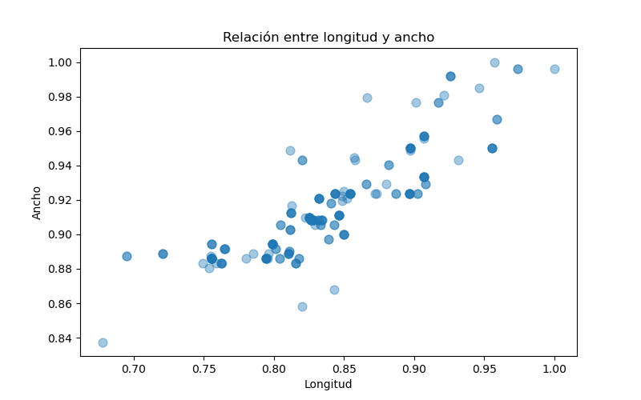

```python
import matplotlib.pyplot as plt

# Sorpresa
%matplotlib widget

# Cerrar figuras abiertas
plt.close('all')

# Dibujar Lienzo
fig = plt.figure(figsize=(8, 5))

# Dibujar Ejes
ax = plt.axes()

# Graficar Nube de Puntos
ax.scatter(df['length'], df['width'], alpha=0.4, s=60)

# Nombres de los Ejes
ax.set_xlabel("Longitud")
ax.set_ylabel("Ancho")

# Título
ax.set_title("Relación entre longitud y ancho")

# Mostrar Imagen (Opcional en JupyterLab)
plt.show()
```

### 3-D

```python
df[['length','width','height']].head()
```

|  | length | width | height |
| --- | --- | --- | --- |
| 0 | 0.811148 | 0.890278 | 48.8 |
| 1 | 0.811148 | 0.890278 | 48.8 |
| 2 | 0.822681 | 0.909722 | 52.4 |
| 3 | 0.848630 | 0.919444 | 54.3 |
| 4 | 0.848630 | 0.922222 | 54.3 |

```python
from mpl_toolkits import mplot3d
```

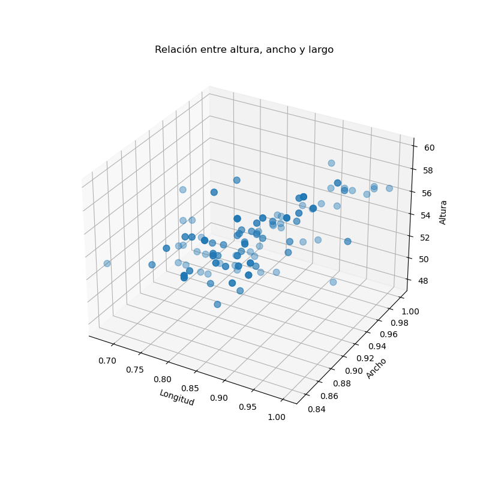

```python
%matplotlib widget

plt.close('all')
fig = plt.figure(figsize=(8, 8))
ax = plt.axes(projection="3d")
ax.scatter3D(df['length'], df['width'], df['height'], alpha=0.4, s=60)
ax.set_xlabel("Longitud")
ax.set_ylabel("Ancho")
ax.set_zlabel("Altura")
ax.set_title("Relación entre altura, ancho y largo ");
```

### 4-D

```python
df[['length','width','height','peak-rpm']].head()
```

|  | length | width | height | peak-rpm |
| --- | --- | --- | --- | --- |
| 0 | 0.811148 | 0.890278 | 48.8 | 5000.0 |
| 1 | 0.811148 | 0.890278 | 48.8 | 5000.0 |
| 2 | 0.822681 | 0.909722 | 52.4 | 5000.0 |
| 3 | 0.848630 | 0.919444 | 54.3 | 5500.0 |
| 4 | 0.848630 | 0.922222 | 54.3 | 5500.0 |

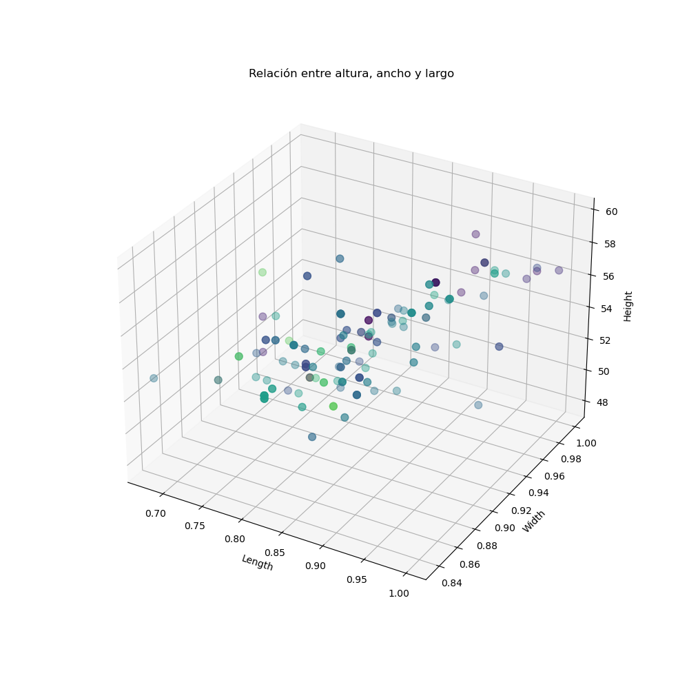

```python
%matplotlib widget
plt.close('all'); fig = plt.figure(figsize=(10, 10))
ax = plt.axes(projection="3d")

ax.scatter3D(df['length'], df['width'], df['height'],
             c = df['peak-rpm'], alpha = 0.4, s=60)

ax.set_xlabel("Length")
ax.set_ylabel("Width")
ax.set_zlabel("Height")

ax.set_title("Relación entre altura, ancho y largo ")
plt.show()
```

### 5-D

```python
df[['length','width','height','peak-rpm','price']].head()
```

|  | length | width | height | peak-rpm | price |
| --- | --- | --- | --- | --- | --- |
| 0 | 0.811148 | 0.890278 | 48.8 | 5000.0 | 13495.0 |
| 1 | 0.811148 | 0.890278 | 48.8 | 5000.0 | 16500.0 |
| 2 | 0.822681 | 0.909722 | 52.4 | 5000.0 | 16500.0 |
| 3 | 0.848630 | 0.919444 | 54.3 | 5500.0 | 13950.0 |
| 4 | 0.848630 | 0.922222 | 54.3 | 5500.0 | 17450.0 |

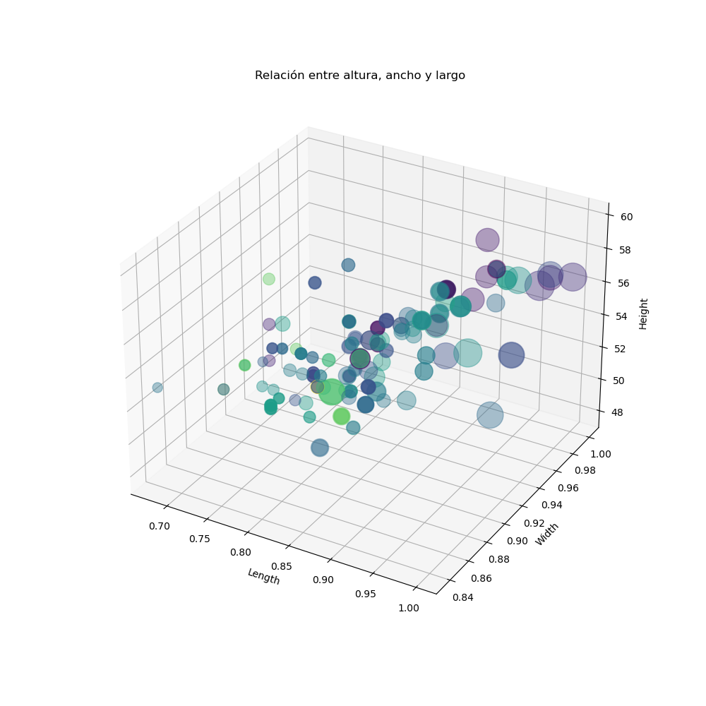

```python
%matplotlib widget
plt.close('all'); fig = plt.figure(figsize=(10, 10))
ax = plt.axes(projection="3d")

ax.scatter3D(df['length'], df['width'], df['height'],
             c = df['peak-rpm'], s = df['price']/50,
             alpha = 0.4)

ax.set_xlabel("Length")
ax.set_ylabel("Width")
ax.set_zlabel("Height")
ax.set_title("Relación entre altura, ancho y largo ")
plt.show()
```

## ¿Para qué todo esto?

## Intuición sobre Clustering

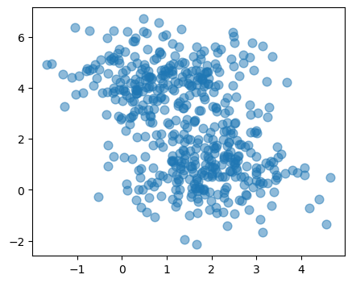

```python
%matplotlib inline
from sklearn.datasets import make_blobs

X, y = make_blobs(n_samples=500, centers=2, n_features=2, random_state=0)

plt.figure(figsize=(5, 4))
plt.scatter(X[:,0],X[:,1],s=60, alpha=0.5)
plt.show()
```

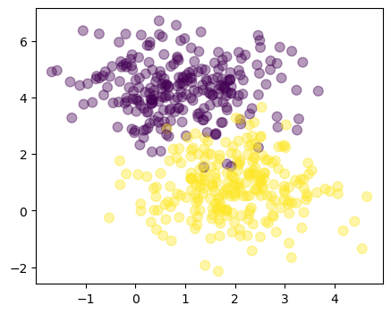

```python
plt.close('all')
plt.figure(figsize=(5, 4))
plt.scatter(X[:,0],X[:,1],s=60, alpha=0.4, c=y)
plt.show()
```

## ¿Más Features, Mejor?

¿Cree usted que tener más features en un problema es mejor para hacer clustering?

**a) ¡Por supuesto!, más info siempre es mejor.**

**b) No, la matemática es inconsistente cuando se tienen muchos features.**

## Fenómeno del Espacio Vacío

\begin{equation*} \lim\limits_{D\to \infty} \frac{V_{sphere}}{V_{cube}} = 0. \end{equation*}

En altas dimensiones un cubo (hiper-cubo) que circunscribe una esfera 𝐷-dimensional tiene forma de [erizo de mar](https://upload.wikimedia.org/wikipedia/commons/9/9b/Tripneustes_ventricosus_%28West_Indian_Sea_Egg-top%29_and_Echinometra_viridis_%28Reef_Urchin_-_bottom%29.jpg).

[figure not shown]

**Why is the curse of dimensionality also called the empty space phenomenon?**

## Maldición de la dimensión

[figure not shown]

## **¿Y si reducimos la dimensionalidad?**

## Reducción de Dimensión

[figure not shown]

Desenvolver el Rollo Suizo. Source: Data Science Heroes. Image free to share.

## A veces, desenvolver no es tan fácil...

[figure not shown]

Banda de Möbius, By [CC BY-SA 3.0](http://creativecommons.org/licenses/by-sa/3.0/), [Link](https://commons.wikimedia.org/w/index.php?curid=50359)

[figure not shown]

Botella de Klein, By [CC BY-SA 3.0](http://creativecommons.org/licenses/by-sa/3.0/), [Link](https://commons.wikimedia.org/w/index.php?curid=960446)

[figure not shown]

Comparación de Métodos con el Rollo Suizo, Source: Jennifer Chu. Image free to share

## Métodos para Visualización

- T-SNE (t-distributed Stochastic Neighbor Embedding).
- SOM (Auto organización).
- LDA (Linear Discriminant Analysis) $\to$ Método Supervisado.

## T-SNE

```python
mnist = pd.read_csv('../datos/mnist_train.csv',header=None)
```

```python
mnist.head(3)
```

|  | 0 | 1 | 2 | 3 | 4 | 5 | 6 | 7 | 8 | 9 | 10 | 11 | 12 | 13 | ... | 771 | 772 | 773 | 774 | 775 | 776 | 777 | 778 | 779 | 780 | 781 | 782 | 783 | 784 |
| --- | --- | --- | --- | --- | --- | --- | --- | --- | --- | --- | --- | --- | --- | --- | --- | --- | --- | --- | --- | --- | --- | --- | --- | --- | --- | --- | --- | --- | --- |
| 0 | 5 | 0 | 0 | 0 | 0 | 0 | 0 | 0 | 0 | 0 | 0 | 0 | 0 | 0 | ... | 0 | 0 | 0 | 0 | 0 | 0 | 0 | 0 | 0 | 0 | 0 | 0 | 0 | 0 |
| 1 | 0 | 0 | 0 | 0 | 0 | 0 | 0 | 0 | 0 | 0 | 0 | 0 | 0 | 0 | ... | 0 | 0 | 0 | 0 | 0 | 0 | 0 | 0 | 0 | 0 | 0 | 0 | 0 | 0 |
| 2 | 4 | 0 | 0 | 0 | 0 | 0 | 0 | 0 | 0 | 0 | 0 | 0 | 0 | 0 | ... | 0 | 0 | 0 | 0 | 0 | 0 | 0 | 0 | 0 | 0 | 0 | 0 | 0 | 0 |

3 rows × 785 columns

```python
labels = mnist.values[:,0]
features = mnist.values[:,1:]
```

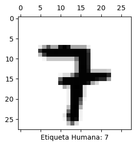

```python
plt.close('all')
fig, ax = plt.subplots(figsize=(3,3))
muestra = np.random.randint(len(X))
ax.matshow(features[muestra].reshape(28,28), cmap="Greys")
ax.set_xlabel(f'Etiqueta Humana: {labels[muestra]}');
```

```python
from sklearn.manifold import TSNE
embedding = TSNE(n_components=2) #result has 2 features
X_transformed = embedding.fit_transform(features[:2000,:])
```

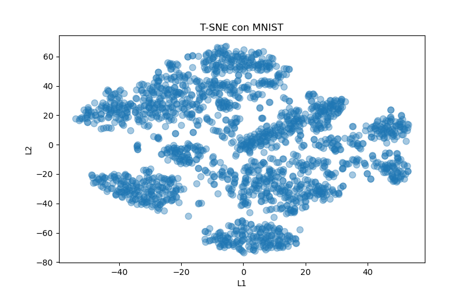

```python
%matplotlib widget
plt.close('all'); fig = plt.figure(figsize=(8, 5))
ax = plt.axes()
ax.scatter(X_transformed[:,0], X_transformed[:,1], alpha=0.4, s=60)
ax.set_xlabel("L1"); ax.set_ylabel("L2")
ax.set_title("T-SNE con MNIST");
```

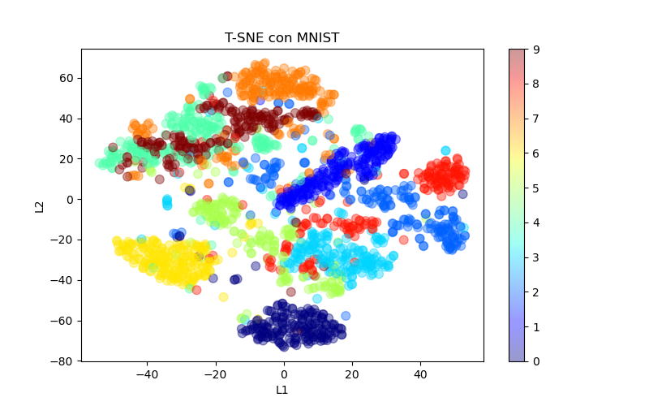

```python
%matplotlib widget
plt.close('all'); fig = plt.figure(figsize=(8, 5))
ax = plt.axes()
sc = ax.scatter(X_transformed[:,0], X_transformed[:,1], alpha=0.4, s=60,c=labels[:2000], cmap='jet')
ax.set_xlabel("L1");ax.set_ylabel("L2")
ax.set_title("T-SNE con MNIST");plt.colorbar(sc);
```

## SOM

**Se contruye un libro de códigos de tal manera que cada dato se puede asociar a un código que esté cerca de otro dato original.**

```python
from minisom import MiniSom
som = MiniSom(30, 30, 64, sigma=4,
              learning_rate=0.5, neighborhood_function='triangle')
som.pca_weights_init(data)
print("Training...")
som.train_random(data, 5000, verbose=False)  # random training
print("\n...ready!")
```

```
Training...

...ready!
```

[figure not shown]

Autoorganización de MNIST, Álvaro Montenegro.

[figure not shown]

Autoorganización de MNIST, Álvaro Montenegro.

## PCA

## **Próximamente, con el profesor Campo Elías**

## ICA

**Se asume que la señal se puede separar en señales independientes.**

[figure not shown]

Método de Reducción ICA.

```python
from sklearn.decomposition import FastICA

embedding = FastICA(n_components=50) #resulting data has 2 dimensions, 'components'
X_transformed = embedding.fit_transform(features[:2000,:]) #fit model and transform
# reconstruct image with independent components
```

[figure not shown]

Datos Originales.

[figure not shown]

Datos Recuperados desde ICA.

## ISOMAP

**La distancia entre puntos se mide a lo largo de la variedad, como medir sobre la tierra y no al estilo euclidiano.**

[figure not shown]

Método de Reducción ISOMAP.

[figure not shown]

Rollo Suizo.

[figure not shown]

Rollo Suizo con ISOMAP.

## LLE

**Intenta descubrir la estructura no lineal en datos de alta dimensión mediante la explotación de las simetrías locales de la reconstrucción lineal.**

[figure not shown]

Rollo Suizo.

[figure not shown]

Rollo Suizo con LLE.

## UMAP

#### **Los invitamos cordialmente al Diplomado en Ciencia de Datos.**

**[UMAP: Uniform Manifold Approximation and Projection for Dimension Reduction](https://umap-learn.readthedocs.io/en/latest/)**

## Ejemplo en Textos

```python
import pandas as pd
tweets = pd.read_csv('../datos/tweets_public.csv')
print(tweets.shape)
tweets.sample(3)
```

```
(7867, 10)
```

|  | airline_sentiment | is_reply | reply_count | retweet_count | text | tweet_coord | tweet_created | tweet_id | tweet_location | user_timezone |
| --- | --- | --- | --- | --- | --- | --- | --- | --- | --- | --- |
| 6080 | negative | True | 0 | 0 | @hmguardado @ugtcatalunya @Iberia @vueling Es ... | NaN | Tue Dec 19 12:21:46 +0000 2017 | 943094002575962114 | Valladolid, España | NaN |
| 1433 | neutral | False | 0 | 0 | Con @Iberia, mi destino a un solo click. ¡Dese... | NaN | Wed Nov 22 11:07:04 +0000 2017 | 933290732206649344 | NaN | NaN |
| 5811 | positive | True | 0 | 0 | @Josetvller @Iberia que lindo avión!!! buen vu... | NaN | Sat Dec 16 14:12:47 +0000 2017 | 942034775396831234 | NaN | NaN |

```python
import sys
sys.path.append('../modulos')
from preprocessing import limpiar_textos

textos = limpiar_textos(tweets['text'])
textos.sample(5)
```

```
Limpiando Texto...    Tiempo de Procesamiento: 0:00:00.109774
```

|  | text | text_limpio |
| --- | --- | --- |
| 4664 | Los pilotos de Ryanair desconvocan la huelga t... | los pilotos de ryanair desconvocan la huelga t... |
| 1039 | Las nuevas propagandas de Iberia me hacen pens... | las nuevas propagandas de iberia me hacen pens... |
| 3321 | Marta Ríos, de la dirección de marketing a la ... | marta ríos, de la dirección de marketing a la ... |
| 5662 | @GuillerCil @lanuevaespana @Iberia @irutze Por... | guillercil lanuevaespana iberia irutze por _fi... |
| 4982 | @Iberia Felicidades IBERIA. | iberia felicidades iberia. |

```python
from sentence_transformers import SentenceTransformer

# Modelos de Inteligencia Artificial
modelo_lenguaje = SentenceTransformer('hiiamsid/sentence_similarity_spanish_es',device='mps')
# Obtener features del texto
features = modelo_lenguaje.encode(textos['text_limpio'].values[:1000], show_progress_bar=True)
```

```python
features_df = pd.DataFrame(features, columns=[f'f{i}' for i in range(1,features.shape[1]+1)])
features_df = pd.concat([textos['text_limpio'].iloc[:1000],features_df],axis=1)
features_df.head(3)
```

|  | text_limpio | f1 | f2 | f3 | f4 | f5 | f6 | f7 | f8 | f9 | f10 | f11 | f12 | f13 | ... | f755 | f756 | f757 | f758 | f759 | f760 | f761 | f762 | f763 | f764 | f765 | f766 | f767 | f768 |
| --- | --- | --- | --- | --- | --- | --- | --- | --- | --- | --- | --- | --- | --- | --- | --- | --- | --- | --- | --- | --- | --- | --- | --- | --- | --- | --- | --- | --- | --- |
| 0 | trabajar en ryanair como tma | 0.739836 | -0.302889 | -0.104906 | -0.749685 | 0.323425 | -0.171454 | 0.753788 | 0.495536 | -0.642342 | -0.333160 | 0.071664 | -0.935447 | 0.191901 | ... | -0.309352 | 0.220056 | 1.031003 | 0.154051 | -0.651995 | -0.362682 | 0.759486 | 0.535673 | 0.748130 | -0.692482 | 0.407046 | 0.388406 | 0.553958 | -0.289300 |
| 1 | iberia fionaferrer cuando gusten en cancún se ... | -0.161136 | 0.318022 | 0.237311 | 0.611276 | -1.253737 | 1.511900 | 1.239177 | 0.774662 | -1.746631 | 0.622404 | 1.070704 | 1.037316 | -0.205809 | ... | 0.012710 | 0.027523 | -0.996960 | 0.127646 | 0.548345 | 0.275060 | 0.311967 | -1.326318 | -0.878262 | -0.475748 | 0.439689 | -1.224960 | -0.537754 | -0.542354 |
| 2 | sabiais que iberia te trata muy bien en santia... | 0.354150 | 0.266248 | 0.384536 | 0.265574 | -0.445051 | 0.384054 | 0.720849 | -0.083288 | 0.122668 | -0.257705 | -0.011474 | 0.100614 | -0.088779 | ... | 0.517726 | 0.008488 | -0.273352 | 0.359657 | 0.622440 | 0.137106 | 0.138903 | 0.429644 | -0.788310 | -0.661639 | -0.451279 | 0.101182 | 0.001042 | 0.200534 |

3 rows × 769 columns

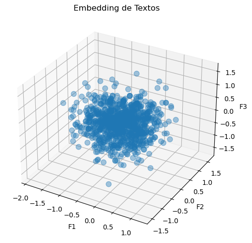

```python
%matplotlib inline
fig = plt.figure(figsize=(6, 6)); ax = plt.axes(projection='3d')
ax.scatter(features_df['f1'], features_df['f2'], features_df['f3'], alpha=0.4, s=60)
ax.set_xlabel("F1");ax.set_ylabel("F2");ax.set_zlabel("F3");ax.set_title("Embedding de Textos");
```

[figure not shown]

Reducción de dimensión con ISOMAP.

**¿Qué pasó con los fractales?**

[Krishna Kumaraswamy, Fractal Dimension for Data Mining](https://www.ml.cmu.edu/research/dap-papers/skkumar_kdd_project.pdf)